# Supervised learning: Nonlinear Regression

## Polynomial regression

3. **Create another linear model pn3_mod, where you add the second and third-degree polynomial terms I(lstat^2) and I(lstat^3) to the formula. Create a pred_plot() with this model.**

```r
pn3_mod <- lm(medv ~ lstat + I(lstat^2) + I(lstat^3), data = Boston)
```

```r
pred_plot(pn3_mod)
```

[output not shown]

4. **Play around with the poly() function. What output does it generate with the arguments `degree = 3` and `raw = TRUE?`**

```r
poly_mod <- lm(medv ~ poly(lstat, degree = 3, raw = TRUE), data = Boston)
```

```r
pred_plot(poly_mod)
```

[output not shown]

5. **Use the poly() function directly in the model formula to create a 3rd-degree polynomial regression predicting `medv` using `lstat`. Compare the prediction plot to the previous prediction plot you made. What happens if you change the poly() function to `raw = FALSE`?**

```r
poly_raw_false_mod <- lm(medv ~ poly(lstat, degree = 3, raw = FALSE), data = Boston)
```

```r
pred_plot(poly_raw_false_mod)
```

[output not shown]

I don’t see a difference…

## Piecewise regression

6. **Create a model called pw2_mod with one predictor: I(lstat <= median(lstat)). Create a pred_plot with this model. Use the coefficients in coef(pw2_mod) to find out what the predicted value for a low-lstat neighbourhood is.**

```r
pw2_mod <- lm(medv ~ I(lstat <= median(lstat)), data = Boston)
```

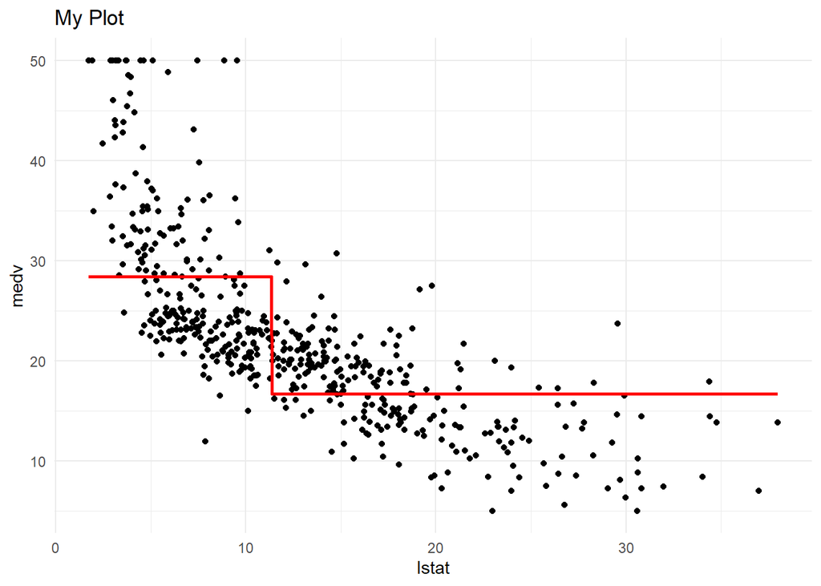

```r
pred_plot(pw2_mod)
```

```r
coef(pw2_mod)
```

```
##                   (Intercept) I(lstat <= median(lstat))TRUE
##                      16.67747                      11.71067
```

The predicted value for low stat neighbourhoods is 16.67747 + 11.71067.

7. **Use the `cut()` function in the formula to generate a piecewise regression model called `pw5_mod` that contains 5 equally spaced sections. Again, plot the result using `pred_plot`.**

```r
pw5_mod <- lm(medv ~ cut(lstat, breaks = 5), data = Boston)
```

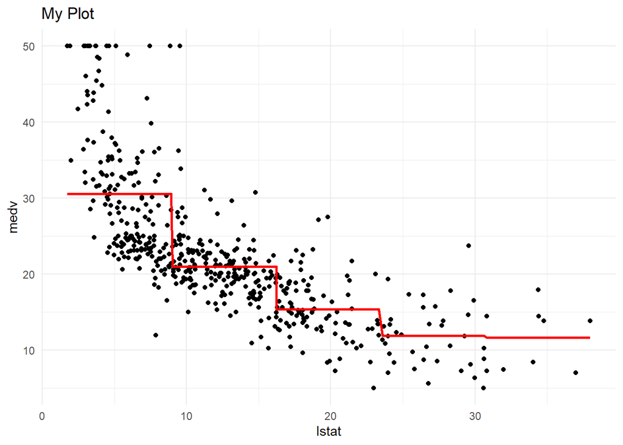

```r
pred_plot(pw5_mod)
```

## Piecewise polynomial regression

```r
# function declaration: has the arguments vec and knots, with default to 1
piecewise_cubic_basis <- function(vec, knots = 1) {

  # if knots are set to 0 we get a 3rd degree polynomial from the vec data
  if (knots == 0) return(poly(vec, degree = 3, raw = TRUE))

  # if we do have knots, we cut the vec data into knots + 1 parts
  cut_vec <- cut(vec, breaks = knots + 1)

  # we declare out to be a column vector with the same length as vec
  out <- matrix(nrow = length(vec), ncol = 0)

  # loop in eat of the parts of cut_vec
  for (lvl in levels(cut_vec)) {
    # setting tmp equal to vec
    tmp <- vec
    # sets the parts we're not in to 0
    tmp[cut_vec != lvl] <- 0
    # sets out to a polynomial fit to each part
    out <- cbind(out, poly(tmp, degree = 3, raw = TRUE))
  }

  #returns out
  out
}
```

9. **This function does not have comments. Copy - paste the function and add comments to each line. To figure out what each line does, you can first create “fake” `vec` and `knots` variables, for example `vec <- 1:20` and `knots <- 2` and try out the lines separately.**

```r
vec <- 1:20
knots <- 2
```

```r
piecewise_cubic_basis(vec, knots)
```

```
##       1  2   3  1   2    3  1   2    3
##  [1,] 1  1   1  0   0    0  0   0    0
##  [2,] 2  4   8  0   0    0  0   0    0
##  [3,] 3  9  27  0   0    0  0   0    0
##  [4,] 4 16  64  0   0    0  0   0    0
##  [5,] 5 25 125  0   0    0  0   0    0
##  [6,] 6 36 216  0   0    0  0   0    0
##  [7,] 7 49 343  0   0    0  0   0    0
##  [8,] 0  0   0  8  64  512  0   0    0
##  [9,] 0  0   0  9  81  729  0   0    0
## [10,] 0  0   0 10 100 1000  0   0    0
## [11,] 0  0   0 11 121 1331  0   0    0
## [12,] 0  0   0 12 144 1728  0   0    0
## [13,] 0  0   0 13 169 2197  0   0    0
## [14,] 0  0   0  0   0    0 14 196 2744
## [15,] 0  0   0  0   0    0 15 225 3375
## [16,] 0  0   0  0   0    0 16 256 4096
## [17,] 0  0   0  0   0    0 17 289 4913
## [18,] 0  0   0  0   0    0 18 324 5832
## [19,] 0  0   0  0   0    0 19 361 6859
## [20,] 0  0   0  0   0    0 20 400 8000
```

10. **Create piecewise cubic models with 1, 2, and 3 knots (pc1_mod - pc3_mod) using this piecewise cubic basis function. Compare them using the pred_plot() function.**

```r
pc1_mod <- lm(medv ~ piecewise_cubic_basis(lstat, knots = 1), data = Boston)
pc2_mod <- lm(medv ~ piecewise_cubic_basis(lstat, knots = 2), data = Boston)
pc3_mod <- lm(medv ~ piecewise_cubic_basis(lstat, knots = 3), data = Boston)
```

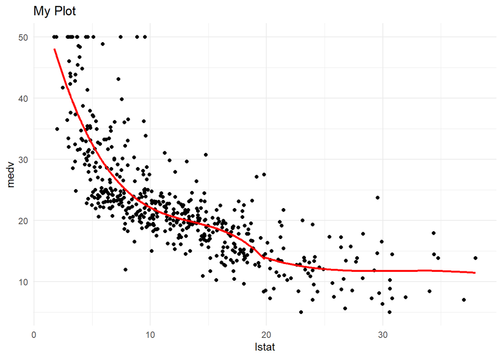

```r
pred_plot(pc1_mod)
```

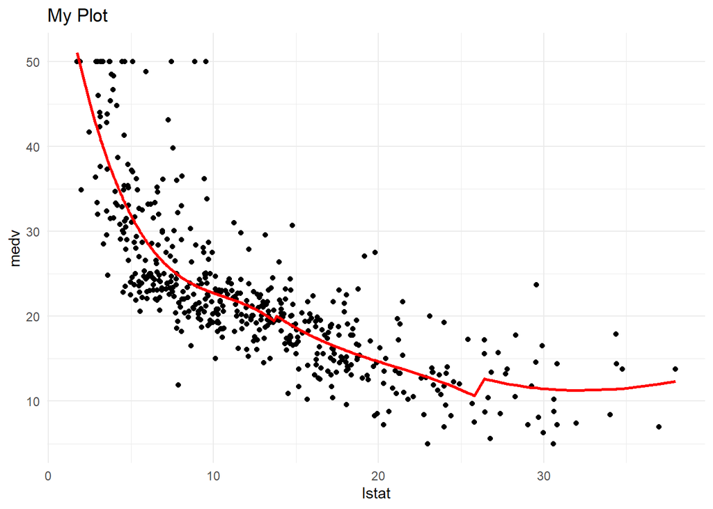

```r
pred_plot(pc2_mod)
```

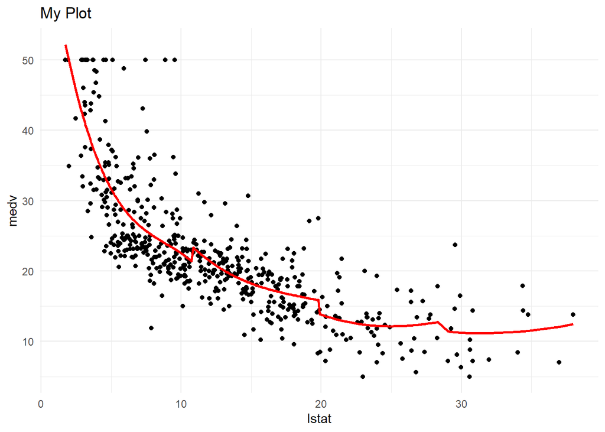

```r
pred_plot(pc3_mod)
```

## Splines

11. **Create a data frame called boston_tpb with the columns medv and lstat from the Boston dataset.**

```r
boston_tpb <-
  Boston %>%
  select(medv, lstat)
```

12. Now use `mutate` to add squared and cubed versions of the `lstat` variable to this dataset.

```r
boston_tpb <-
  boston_tpb %>%
  mutate(lstat_squared = lstat^2, lstat_cubed = lstat^3)
```

13. **Use `mutate` to add a column `lstat_tpb` to this dataset which is 0 below the median and has value `(lstat - median(lstat))^3` above the median. Tip: you may want to use `ifelse()` within your `mutate()` call.**

```r
boston_tpb <-
  boston_tpb %>%
  mutate(lstat_tpb = ifelse(lstat < median(lstat), 0, (lstat - median(lstat))^3))
```

14. **Create a linear model `tpb_mod` using the `lm()` function. How many predictors are in the model? How many degrees of freedom does this model have?**

```r
tpb_mod <- lm(medv ~ ., data = boston_tpb)
```

15. **Create a cubic spline model `bs1_mod` with a knot at the median using the `bs()` function. Compare its predictions to those of the `tpb_mod` using the `predict()` function on both models.**

```r
bs1_mod <- lm(medv ~ bs(lstat, knots = median(lstat), degree = 3), data = Boston)
tpb_pred <- predict(tpb_mod)
```

```r
bs1_pred <- predict(bs1_mod)
```

```r
mean(abs(tpb_pred - bs1_pred))
```

```
## [1] 3.449994e-13
```

16. **Create a prediction plot from the `bs1_mod` object using the `plot_pred()` function.**

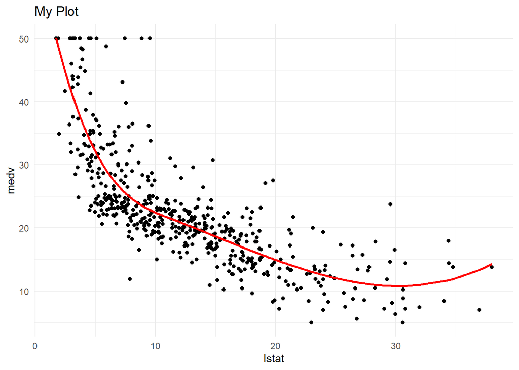

```r
pred_plot(bs1_mod)
```

17. **Create a natural cubic spline model (`ns3_mod`) with 3 degrees of freedom using the `ns()` function. Plot it, and compare it to the `bs1_mod`.**

```r
ns3_mod <- lm(medv ~ ns(lstat, df = 3), data = Boston)
```

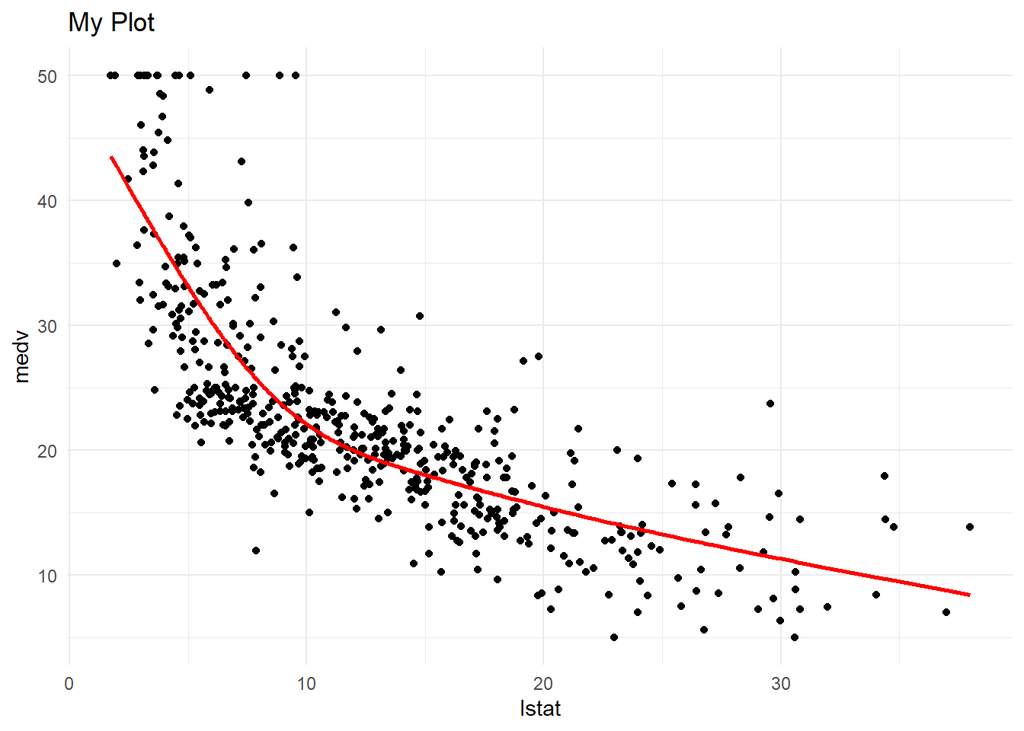

```r
pred_plot(ns3_mod)
```

18. **Plot `lin_mod`, `pn3_mod`, `pw5_mod`, `pc3_mod`, `bs1_mod`, and `ns3_mod` and give them nice titles by adding + ggtitle(“My title”) to the plot. You may use the function plot_grid() from the package cowplot to put your plots in a grid.**

```r
lin_plot <- pred_plot(lin_mod, "lin")
pn3_plot <- pred_plot(pn3_mod, "pn3")
pw5_plot <- pred_plot(pw5_mod, "pw5")
pc3_plot <- pred_plot(pc3_mod, "pc3")
bs1_plot <- pred_plot(bs1_mod, "bs1")
ns3_plot <- pred_plot(ns3_mod, "ns3")
```

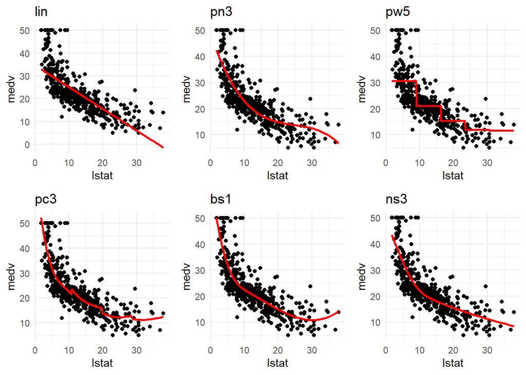

```r
cowplot::plot_grid(lin_plot, pn3_plot, pw5_plot, pc3_plot, bs1_plot, ns3_plot)
```

## Programming assignment (optional)